# SS Analysis

John Lee

Sunday, October 25, 2015

Priviledged and Confidential. Not to be copied or reproduced without the expressed written consent of the author.

# Executive Summary

This report analyzes the searchlog, clickstream and appointment data spanning 8/15/15 to 8/31/15, provided by SS. The objectives of this analysis are to a) define the KPIs and benchmarks b) define user cluster and preliminary personas, based on the data.

# Preliminary Data Processing

Load data into R and prepare tidy data frames.

```r
#  Set working directory and load raw data into dataframes
setwd("C:/Users/jlee/Documents/Personal/SS")
appt <- read.table('appointments_08150901.tsv', header=TRUE, sep="\t")
# clickstream <- read.csv("clickstream_08150901.csv",header=TRUE)
searchlog <- read.csv("searchlog_08150901.csv",header=TRUE)
searchlog$query <- tolower(searchlog$query)

#  Create nominal variables of search parameters to be used in summarization
hasdate <- as.numeric(grepl("start_date=2015",searchlog$api_url)) #search by date
loctype <- rep("default",times = length(searchlog$location)) #search by type of location
loctype[grepl("[0-9]{5}",searchlog$location)] <- "zip"
loctype[grepl("[a-zA-Z]",searchlog$location)] <- "city"
prodtype <- rep("custom",times = length(searchlog$location)) #seach by product
prodtype[searchlog$query == "haircut style barber braids weaves extensions nails makeup color massage relaxer wax updo facial blowout"] <- "all"
prodtype[grepl("^hair cut$",searchlog$query)] <- "hair cut"
prodtype[grepl("^style$",searchlog$query)] <- "style"
prodtype[grepl("^barber$",searchlog$query)] <- "barber"
prodtype[grepl("^braids$",searchlog$query)] <- "braids"
prodtype[grepl("^weaves & extensions$",searchlog$query)] <- "w & e"
prodtype[grepl("^nails$",searchlog$query)] <- "nails"
prodtype[grepl("^makeup$",searchlog$query)] <- "makeup"
prodtype[grepl("^color$",searchlog$query)] <- "color"
hasprice <- as.numeric(grepl("(max_price=|min_price=)",searchlog$api_url)) #search by price
bookable <- as.numeric(grepl("online_bookable=",searchlog$api_url)) #search by online booking
autocharge <- as.numeric(grepl("autocharge_enabled=",searchlog$api_url)) #search by ExpressPay
brands <- as.numeric(grepl("selected_brand=",searchlog$api_url)) #search by brand
login <- rep(0,times = length(searchlog$location)) #search by whether user is logged in or not
login[!searchlog$user_id == "NULL"] <- 1

#  Create binary variables for key search parameters to be used in clustering and summarization.  Append binary variables to search dataset.
search <- searchlog
search <- cbind(search,bookable,login,loctype,prodtype)
search$bookable <- as.factor(search$bookable)
search$login <- as.factor(search$login)
search$loc_city <- 0
search$loc_city[loctype == "city"] <- 1
search$loc_zip <- 0
search$loc_zip[loctype == "zip"] <- 1
search$loc_default <- 0
search$loc_default[loctype == "default"] <- 1
search$prod_custom <- 0
search$prod_custom[prodtype == "custom"] <- 1
search$prod_all <- 0
search$prod_all[prodtype == "all"] <- 1
search$prod_haircut <- 0
search$prod_haircut[prodtype == "hair cut"] <- 1
search$prod_style <- 0
search$prod_style[prodtype == "style"] <- 1
search$prod_barber <- 0
search$prod_barber[prodtype == "barber"] <- 1
search$prod_braids <- 0
search$prod_braids[prodtype == "braids"] <- 1
search$prod_we <- 0
search$prod_we[prodtype == "w & e"] <- 1
search$prod_nails <- 0
search$prod_nails[prodtype == "nails"] <- 1
search$prod_makeup <- 0
search$prod_makeup[prodtype == "makeup"] <- 1
search$prod_color <- 0
search$prod_color[prodtype == "color"] <- 1
search$book <- as.numeric(search$bookable) - 1
search$loggedin <- as.numeric(search$login) - 1
search$search_count <- 1

#  Merge (i.e. left join) search and appointment data into "m1" dataset
m1 <- merge(search, appt, by.x="id", by.y="id", all.x = TRUE)
m1$appt_count <- as.numeric(!is.na(m1$provider_id))
```

# Exploratory Data Analysis

Analysis of searchlog data indicates no searches exist with a “page” parameter in api_url, which would result if user scrolled to page two of results. This suggests the searchlog data represents users’ **initial** searches only.

The table below shows the number of searches by search parameter. Zero (“0”) indicates that the parameter is not present, whereas a one (“1”) indicates that the search contains the parameter.

```r
searchmix <- as.data.frame(cbind(autocharge,bookable,brands,hasdate,hasprice,login,loctype,prodtype))
library(scales)
summary(searchmix)
```

```
##  autocharge bookable   brands     hasdate    hasprice   login
##  0:188525   0:132448   0:190489   0:180843   0:183154   0:115846
##  1:  2172   1: 58249   1:   208   1:  9854   1:  7543   1: 74851
##
##
##
##
##
##     loctype           prodtype
##  city   : 40344   custom  :58547
##  default:143623   all     :32996
##  zip    :  6730   hair cut:22479
##                   color   :19414
##                   w & e   :17399
##                   braids  :12713
##                   (Other) :27149
```

The table above indicates:

- There are few searches involving Expresspay (autocharge), Brands (brands), Date (hasdate) and Price (hasprice). As a result, these parameters can be excluded in the subsequent clustering analysis.
- The Date parameter can become a facet/filter option displayed after the initial search as oppose to a primary search parameter
- Looking at location types (i.e. “loctype”), we see that 75.3% of searches were for the default, pre-populated location (records with location = NULL in searchlog dataset). 21.2% of searches were by user specified city, and only 3.53% of searches were by Zip Code.

Generate summary of searches by product:

```r
suppressMessages(library(dplyr))
prodmix <- prop.table(table(searchmix$prodtype))
prodmix <- as.data.frame(prodmix)
names(prodmix) <- c("product","pctTotal")
prodmix <- arrange(prodmix, desc(pctTotal))
prodmix$pctTotal <- percent(prodmix$pctTotal)
print(prodmix)
```

```
##     product pctTotal
## 1    custom    30.7%
## 2       all    17.3%
## 3  hair cut    11.8%
## 4     color    10.2%
## 5     w & e     9.1%
## 6    braids     6.7%
## 7     style     5.2%
## 8     nails     3.4%
## 9    makeup     3.0%
## 10   barber     2.7%
```

The product mix table above indicates:

- 30.7% of searches were for a custom, user specified keyword. We suspect that the majority of such searches were for specific Stylists.
- 17.3% of searches were for a general product search (denoted as “all” in the table below). This is either due to users clearing out the product field or from sharing of deep link search URLs as part of advertising campaigns (per Greg Garson).
- 11.8% of searches were for “Hair Cut”, which is the default on the website

Finally, after merging searchs and appointment datasets, we find that only **27** appointments were as a result of searches in the searchlog dataset. This appears too low given the search volume. This analysis utilizes this appointment count going forward, but it should be validated with SS personnel.

```r
options(scipen=999)
sum(m1$appt_count)
```

```
## [1] 27
```

# Search Performance KPIs

The follow KPIs are important for search. These KPIs should be monitored at several levels: Overall, By Product and By Location type. In addition, KPIs should be tracked and trended over time.

1. Appointments per Search (and $ per Search)
2. Results per Search
3. Clicks per Search
4. Zero Results Searches

### Overall

Following are the overall metrics calculated from the data provided:

1. Appointments per Search = 0.0001416. As noted above, appointments related to searches appear too low and should be validated with SS.
2. Results per Search = 444.4046209
3. Clicks per Search = 0.279244
4. Zero Results Searches = 2253 searches

### By Product

Below are the Search Performance KPIs by products searched, ordered by “Clicks per Search” from highest to lowest.

```r
byprod <- aggregate(cbind(appt_count,num_found,clicklog_count,search_count) ~ prodtype,m1,sum)
byprod <- mutate(byprod, appt_per_search = appt_count / search_count, results_per_search = num_found / search_count, click_per_search = clicklog_count / search_count)
byprod <- arrange(byprod,desc(click_per_search))
print(byprod)
```

```
##    prodtype appt_count num_found clicklog_count search_count
## 1    makeup          3    896405           4267         5665
## 2    braids          1   2424718           5746        12713
## 3     w & e          1  11745906           6507        17399
## 4  hair cut          2  13159298           8357        22479
## 5    custom          8  18084751          18563        58547
## 6     nails          0    477921           1687         6475
## 7     style          3   3550211           2218         9928
## 8    barber          0    423268            935         5081
## 9       all          3  20561233           3839        32996
## 10    color          6  13422917           1132        19414
##    appt_per_search results_per_search click_per_search
## 1    0.00052956752          158.23566       0.75322154
## 2    0.00007865964          190.72744       0.45197829
## 3    0.00005747457          675.09087       0.37398701
## 4    0.00008897193          585.40407       0.37176921
## 5    0.00013664236          308.89287       0.31706151
## 6    0.00000000000           73.81019       0.26054054
## 7    0.00030217566          357.59579       0.22340854
## 8    0.00000000000           83.30407       0.18401889
## 9    0.00009092011          623.14320       0.11634744
## 10   0.00030905532          691.40399       0.05830844
```

From the table above we observe:

- There is significant variability in both “Results per Search”" and “Clicks per Search” across products
- “Makeup” generates the highest “Click per Search” on fewer “Results per Search”
- In contrast, “Color” generates the lowest “Click per Search” on the highest “Results per Search”
- The “All” (i.e. default) product category follows “Color” with the second lowest “Clicks per Search”

The scatter plot below shows the invese relationship between “Results per Search” and “Clicks per Search” across product searches. As the number of Stylists returned increases, results become less relevant to the user and thus generate less “Clicks per Search.” This suggests improvements are needed to the search algorithms employed.

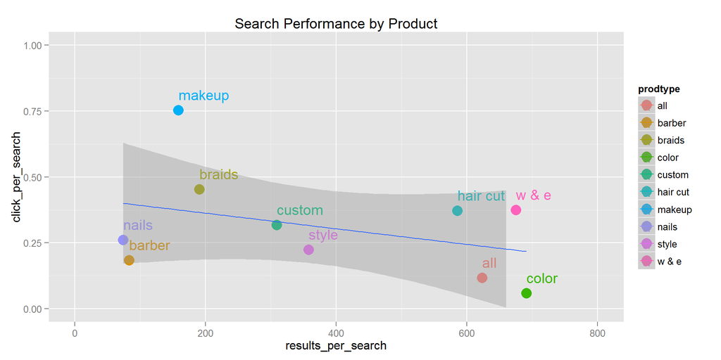

```r
library(ggplot2)
q <- ggplot(byprod,aes(results_per_search,click_per_search,color=prodtype,label=prodtype))
q <- q + geom_point(size=5) + geom_text(size=5, hjust = 0, vjust = -1) + geom_smooth(method="lm", aes(group=1)) + ggtitle("Search Performance by Product") + scale_y_continuous(limit = c(0, 1)) + scale_x_continuous(limit = c(0, 800))
q
```

### By Location Type

Below are the Search Performance KPIs by Location Types, ordered by “Clicks per Search” from highest to lowest.

```r
byloc <- aggregate(cbind(appt_count,num_found,clicklog_count,search_count) ~ loctype,m1,sum)
byloc <- mutate(byloc, appt_per_search = appt_count / search_count, results_per_search = num_found / search_count, click_per_search = clicklog_count / search_count)
byloc <- arrange(byloc,desc(click_per_search))
byloc
```

```
##   loctype appt_count num_found clicklog_count search_count appt_per_search
## 1     zip          1    503067           6158         6730    0.0001485884
## 2    city          5  17638731          33975        40344    0.0001239342
## 3 default         21  66604830          13118       143623    0.0001462161
##   results_per_search click_per_search
## 1           74.74993       0.91500743
## 2          437.20828       0.84213266
## 3          463.74766       0.09133635
```

From the table above we observe:

- Searches where user specifies Zip Code or City have high “Click per Search”
- For Zip Code searches, the “Results per Search” are also quite low, indicating that very focused and relevant results returned to the user
- However, the vast majority of searches are for default locations, which generate very high “Results per Search” but very low “Click per Search,” at about one-tenth that of Zip Code searches

The scatter plot below shows “Results per Search” and “Clicks per Search” for the different location types. Default locations should be tracked more granularly, and further disected to improve relevancy to user.

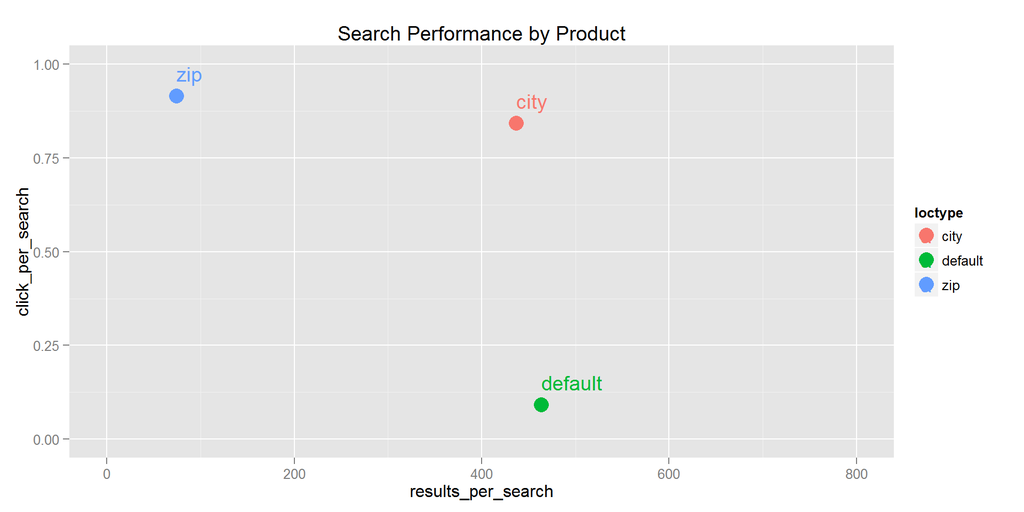

```r
q <- ggplot(byloc,aes(results_per_search,click_per_search,color=loctype,label=loctype))
q <- q + geom_point(size=5) + geom_text(size=5, hjust = 0, vjust = -1) + ggtitle("Search Performance by Product") + scale_y_continuous(limit = c(0, 1)) + scale_x_continuous(limit = c(0, 800))
q
```

# User Clusters and Personas

From the searchlog data, user segments are derived using a Hierachical Clustering. Once defined, clusters are profiled and preliminary personas are described.

```r
#  Conduct hierarchical clustering of user searchlog data.  Given computing limitations, searchlog data is sampled.  The process is repeated many times for different samples to ensure that the number and definitions of clusters are stable.  Through this process, 6 clusters were defined.
set.seed(3443) # remove seed to generate new scenario
suppressWarnings(library("cluster"))
pct_to_sample <-.05 #5 pct sample
df1_sample<-m1[sample(1:nrow(m1),nrow(m1)*pct_to_sample),]
df1_dist <- daisy(df1_sample[,11:14], metric="gower")
hclustering <- hclust(df1_dist,method="average")
```

The dendrogram below shows the results of the hierarchical clustering. From the dendrogarm, 6 primary clusters of users are observed.

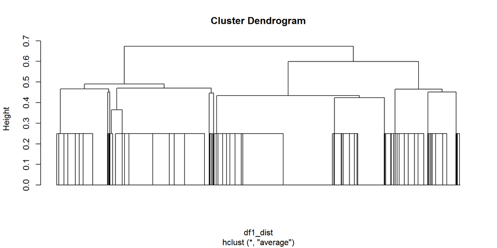

```r
plot(hclustering,labels=FALSE,hang=0)
```

Below are the relative size of each user cluster, based on the propotion of searches in each.

```r
tree_cut<-cutree(hclustering,6)  # 6 clusters were defined through clustering.  Cut the tree to generate 6 clusters
df1_sample$cluster <- tree_cut #Add the cluster membership back to the sampled search dataset
cluster_profiles <-aggregate(df1_sample[,c(7,15:30,38),],by=list(cluster=df1_sample$cluster),FUN=sum)
clustmix <- prop.table(table(df1_sample$cluster))
clustmix <- as.data.frame(clustmix)
names(clustmix) <- c("cluster","pctTotal")
clustmix <- arrange(clustmix, desc(pctTotal))
clustmix$pctTotal <- percent(clustmix$pctTotal)
print(clustmix)
```

```
##   cluster pctTotal
## 1       1    44.6%
## 2       2    24.6%
## 3       3    16.4%
## 4       4    12.6%
## 5       5     1.3%
## 6       6     0.6%
```

Create and display profiles for each cluster.

```r
# Aggregate by cluster. Convert to percentage of the cluster.
cluster_profiles$clicklog_count <- (cluster_profiles$clicklog_count/cluster_profiles$search_count)
names(cluster_profiles)[2] <- "clicks_per_search"
cluster_profiles$loc_city <- percent(cluster_profiles$loc_city/cluster_profiles$search_count)
cluster_profiles$loc_zip <- percent(cluster_profiles$loc_zip/cluster_profiles$search_count)
cluster_profiles$loc_default <- percent(cluster_profiles$loc_default/cluster_profiles$search_count)
cluster_profiles$prod_custom <- percent(cluster_profiles$prod_custom/cluster_profiles$search_count)
cluster_profiles$prod_all <- percent(cluster_profiles$prod_all/cluster_profiles$search_count)
cluster_profiles$prod_haircut <- percent(cluster_profiles$prod_haircut/cluster_profiles$search_count)
cluster_profiles$prod_style <- percent(cluster_profiles$prod_style/cluster_profiles$search_count)
cluster_profiles$prod_barber <- percent(cluster_profiles$prod_barber/cluster_profiles$search_count)
cluster_profiles$prod_braids <- percent(cluster_profiles$prod_braids/cluster_profiles$search_count)
cluster_profiles$prod_we <- percent(cluster_profiles$prod_we/cluster_profiles$search_count)
cluster_profiles$prod_nails <- percent(cluster_profiles$prod_nails/cluster_profiles$search_count)
cluster_profiles$prod_makeup <- percent(cluster_profiles$prod_makeup/cluster_profiles$search_count)
cluster_profiles$prod_color <- percent(cluster_profiles$prod_color/cluster_profiles$search_count)
cluster_profiles$book <- percent(cluster_profiles$book/cluster_profiles$search_count)
cluster_profiles$loggedin <- percent(cluster_profiles$loggedin/cluster_profiles$search_count)
print(cluster_profiles)
```

```
##   cluster clicks_per_search loc_city loc_zip loc_default prod_custom
## 1       1         0.3150717    28.7%    5.5%         66%       44.7%
## 2       2         0.1323090     0.0%    0.0%        100%       24.1%
## 3       3         0.3751601    43.0%    6.1%         51%       23.0%
## 4       4         0.1044277     0.0%    0.0%        100%        7.3%
## 5       5         1.6333333    87.5%   12.5%          0%       32.5%
## 6       6         2.5593220    91.5%    8.5%          0%        5.1%
##   prod_all prod_haircut prod_style prod_barber prod_braids prod_we
## 1    26.5%         7.7%      3.01%       1.25%        4.3%    6.6%
## 2    19.9%        10.7%      4.65%       5.68%        4.7%    6.8%
## 3     0.3%        19.8%      7.62%       3.84%       13.6%   15.9%
## 4     0.0%        19.1%      9.77%       0.00%        7.8%   15.2%
## 5    20.8%        10.8%      0.83%       0.00%        0.8%    9.2%
## 6     0.0%        18.6%      1.69%       0.00%       11.9%   28.8%
##   prod_nails prod_makeup prod_color book loggedin search_count appt_count
## 1      1.58%        1.8%       2.5%   0%       0%         4253          0
## 2      4.27%        2.4%      16.9%   3%     100%         2343          0
## 3      4.42%        4.0%       7.5% 100%       0%         1562          0
## 4      7.77%        4.1%      29.0% 100%     100%         1197          1
## 5      0.83%       24.2%       0.0%   0%     100%          120          0
## 6      8.47%       15.3%      10.2% 100%     100%           59          0
```